# EDA buscas

Aline Costa

O objeto principal da análise são as buscas e a navegação depois da busca. Criamos esses dados a partir dos dados originais da wikimedia em `/data/search_data.csv`.

Aqui, exploramos esses dados.

```r
library(tidyverse)
library(here)
library(lubridate)
theme_set(theme_bw())
```

```r
buscas = read_csv(here::here("data/search_data.csv"))
```

```r
buscas %>%
    ggplot(aes(x = results)) +
    geom_histogram(binwidth = 5)
```

[output not shown]

### What is our daily overall clickthrough rate? How does it vary between the groups?

Passando os dias, como a média vai evoluindo? Depois add os grupos.

Criando uma coluna de data, derivada da coluna session_start_date.

Para analisar a variação de cliques ao longo dos dias, vamos considerar que a média de cliques é a média geral de cliques em cada dia.

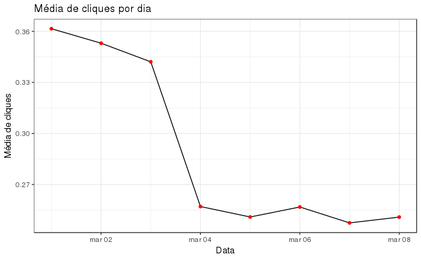

Observando a visualização acima pordemos ver que, de modo geral, a média de cliques é sempre menor que 1. Isso pode ser explicado pelo grande número de pesquisas onde o usuário não clica em nenhum resultado.

Vamos ver se essa observação se mantém analisando os grupos ‘a’ e ‘b’ separadamente:

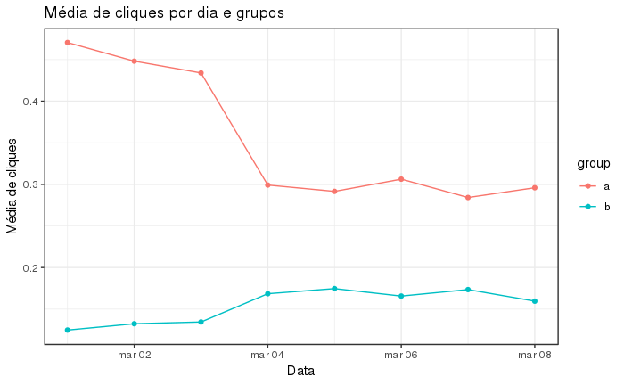

A média de cliques se mantém menor que 1 considerando os grupos separadamente, no entanto, é mais fácil notar alguma diferença entre eles. Para o grupo ‘a’, a média de cliques é mais alta que as média para o grupo ‘b’, considerando nossos dados.

### Which results do people tend to try first? How does it change day-to-day?

Quais resultados as pessoas tendem a tentar primeiro? Como isso muda no dia-a-dia?

Vamos ver primeiro os 16 resultados mais clicados. Ressaltando que removemos os casos onde não houve clique em nenhum link.

```r
busca_com_contagem_cliques <- buscas %>%
  group_by(first_click) %>%
  summarise(count_click = n()) %>%
    arrange(desc(count_click)) %>%
    top_n(16)

busca_com_contagem_cliques %>%
    filter (first_click != "NA") %>%
    ggplot(aes(x = first_click, y = count_click)) +
    geom_point() +
    scale_y_continuous(limits=c(0, 25000)) +
    scale_x_continuous(breaks=seq(1, 20, 1)) +
    labs(
        y = "Quantidade de vezes que foi clicado primeiro",
        x = "Posição do resultado nas 16 posições mais clicadas",
        title = "Classificação do primeiro clique para os resultados da busca")
```

[output not shown]

Para analisar a distribuição dos cliques ao longo dos dias vamos tentar comparar os dias da semana.

```r
buscas_com_data %>%
    filter (first_click < 25) %>%
    ggplot(aes(color = data, x = first_click, alpha=0.5)) +
    geom_density() +
    labs(
        y = "Densidade",
        x = "Posição do 1º clique no resultado da busca",
        title = "Distribuição dos primeiros cliques ao longo dos dias ")
```

[output not shown]

```r
buscas_com_data %>%
    filter (first_click < 25) %>%
    ggplot(aes(x = first_click, fill = data)) +
    geom_histogram(binwidth = 2, na.rm = TRUE) +
    facet_wrap(~ data, nrow=2) +
    labs(
        y = "Densidade",
        x = "Posição do 1º clique no resultado da busca",
        title = "Distribuição dos primeiros cliques ao longo dos dias ")
```

[output not shown]

Para visualizar melhor as diferenças, fixar uma porcentagem e ver quais posições são clicadas por aquele pessoal OU fixar a posição e ver quantos por cento clicam nela.

### What is our daily overall zero results rate? How does it vary between the groups?

Qual é a nossa taxa de resultados zero no geral? Como isso varia entre os grupos?

Vamos ver a distribuição de resultados zero ao longo dos dias.

```r
buscas_com_data %>%
    filter(results == 0) %>%
    ggplot(aes(x = data)) +
    geom_bar() +
    labs(
        y = "Quantidade de buscas com zero resultados",
        x = "Data",
        title = "Distribuição de buscas com zero resultados ao longo dos dias ")
```

[output not shown]

Para visualizar melhor a proporção de resultados zero vamos adicionar também a quantidade total de buscas.

Criando a coluna de é busca “eh_zero”

```r
buscas_com_results_zero <- buscas_com_data %>%
    mutate(eh_resultado_zero = results == 0)
```

```r
buscas_com_results_zero %>%
    filter(!is.na(results) & !is.na(data)) %>%
    ggplot(aes(data, fill=eh_resultado_zero)) +
    geom_bar(position=position_dodge()) +
    labs(
        y = "Quantidade de buscas com zero resultados",
        x = "Data",
        title = "Distribuição de buscas com zero resultados ao longo dos dias ", fill="Resultado zero")
```

[output not shown]

No geral, a quantidade de resultados zero retornados por cada grupo.

```r
buscas_com_data %>%
    filter(!is.na(results) & results == 0) %>%
    ggplot(aes(x = group, fill=group)) +
    geom_bar() +
    labs(
        y = "Quantidade de buscas com zero resultados",
        x = "Grupo",
        title = "Distribuição de buscas com zero resultados pelos grupos ")
```

[output not shown]

### Let session length be approximately the time between the first event and the last event in a session. Choose a variable from the dataset and describe its relationship to session length. Visualize the relationship.

A duração da sessão é aproximadamente o tempo entre o primeiro e o último evento de uma sessão. Escolha uma variável do conjunto de dados e descreva sua relação com o tamanho da sessão. Visualize o relacionamento.

Vamos estudar a relação da quantidade de cliques com o tamanho da sessão.

Vendo a distribuição dos dados para as variáveis session_length e num_clicks

```r
buscas_com_data %>%
    ggplot(aes(x = session_length, y = num_clicks)) +
    geom_point()
```

[output not shown]

Desconsiderando os registros de session_length zero

```r
buscas_com_data %>%
    filter (session_length != 0) %>%
    ggplot(aes(x = session_length, y = num_clicks)) +
    geom_point()
```

[output not shown]

Vamos ver como é distribuído o tamanho das sessões.

```r
buscas_com_data %>%
    filter (session_length != 0) %>%
    ggplot(aes(x = session_length)) +
    geom_density()
```

[output not shown]

Vamos analisar a distribuição aplicando o log de base 10 e vendo para grupos diferentes.

```r
buscas_com_data %>%
    filter (session_length != 0) %>%
    ggplot(aes(x = session_length, y = num_clicks)) +
    geom_point() +
    scale_x_continuous(trans = 'log10') +
    facet_wrap(~ group)
```

[output not shown]

Mais cliques em sessões de tamanho médio?

Para confirmar/refutar vamos ver os valores de correlação:

```r
buscas_com_data %>%
    summarise(
    pearson = cor(session_length, num_clicks, method = "pearson"),
    spearman = cor(session_length, num_clicks, method = "spearman"),
    kendall = cor(session_length, num_clicks, method = "kendall")
  )
```

[output not shown]

Para o grupo ‘a’

```r
buscas_com_data %>%
    filter(group == 'a') %>%
    summarise(
    pearson = cor(session_length, num_clicks, method = "pearson"),
    spearman = cor(session_length, num_clicks, method = "spearman"),
    kendall = cor(session_length, num_clicks, method = "kendall")
  )
```

[output not shown]

Para o grupo ‘b’

```r
buscas_com_data %>%
    filter(group == 'b') %>%
    summarise(
    pearson = cor(session_length, num_clicks, method = "pearson"),
    spearman = cor(session_length, num_clicks, method = "spearman"),
    kendall = cor(session_length, num_clicks, method = "kendall")
  )
```

[output not shown]